# R for Data Science

This notebook attempts to navigate Hadley Wickham’s [R for Data Science](http://r4ds.had.co.nz/index.html).

```r
library(tidyverse)
```

### Chapter 3 - Data Visualization

Initial question: Do cars with big engines use more fuel than cars with small engines? What does the relationship between engine size and fuel efficiency look like?

```r
mpg %>% head
```

```
## # A tibble: 6 x 11
##   manufacturer model displ  year   cyl trans drv     cty   hwy fl    class
##   <chr>        <chr> <dbl> <int> <int> <chr> <chr> <int> <int> <chr> <chr>
## 1 audi         a4      1.8  1999     4 auto… f        18    29 p     comp…
## 2 audi         a4      1.8  1999     4 manu… f        21    29 p     comp…
## 3 audi         a4      2    2008     4 manu… f        20    31 p     comp…
## 4 audi         a4      2    2008     4 auto… f        21    30 p     comp…
## 5 audi         a4      2.8  1999     6 auto… f        16    26 p     comp…
## 6 audi         a4      2.8  1999     6 manu… f        18    26 p     comp…
```

To characterize the variables a little better, `displ` measures engine displacement, in litres, `year` corresponds to the year the car was manufactured, `drv` corresponds to front-wheel drive, rear-wheel drive, or four-wheel drive, `cty` is city miles per gallon, `hwy` is highway miles per gallon, and `fl` is fuel type.

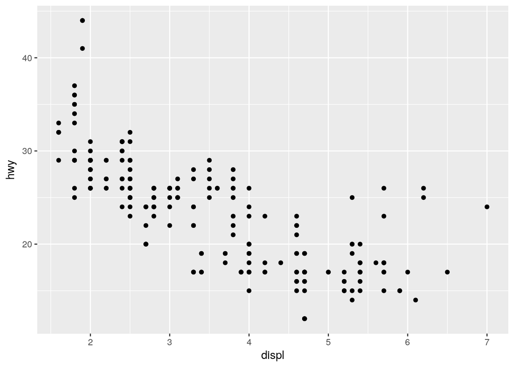

```r
ggplot(data=mpg) +
    geom_point(mapping=aes(x=displ, y=hwy))
```

This graph illustrates that fuel efficiency drops with increasing engine displacement (size). This confirms our hypothesis.

This also goes to show some ggplot2 basics:

1. Start with a call to `ggplot(data=<...>)`
2. Add on layers using `geom` functions
3. Supply `aes`(thetic) mappings to these `geom` functions to put the layer (with `x` and `y` variables) onto the plot.

More specifically, you can use the following as a plot template, replacing bracketed (`<...>`) sections:

```r
ggplot(data = <DATA>) +
  <GEOM_FUNCTION>(mapping = aes(<MAPPINGS>))
```

### Chapter 4 - Workflow Basics

### Chapter 5 - Data Transformation